# Week 5

This week we have used the data from United Nations Development Programme, Human Development Reports ([hdr.undp.org](http://hdr.undp.org/en/content/human-development-index-hdi)).

From the reports, the two data sets of Human Development Index (HDI) and Gender Inequality Index were downloaded, combined, and some data variables were selected for this week’s analysis exercise.

```r
# Load the human.txt data into R.

human<-read.table("~/Desktop/IODS-project/data/human.txt", sep="", header=T)

# Explore the structure and the dimensions of the data
str(human)
```

```
## 'data.frame':    155 obs. of  8 variables:
##  $ Edu2.FM  : num  1.007 0.997 0.983 0.989 0.969 ...
##  $ Labo.FM  : num  0.891 0.819 0.825 0.884 0.829 ...
##  $ Edu.Exp  : num  17.5 20.2 15.8 18.7 17.9 16.5 18.6 16.5 15.9 19.2 ...
##  $ Life.Exp : num  81.6 82.4 83 80.2 81.6 80.9 80.9 79.1 82 81.8 ...
##  $ GNI      : int  64992 42261 56431 44025 45435 43919 39568 52947 42155 32689 ...
##  $ Mat.Mor  : int  4 6 6 5 6 7 9 28 11 8 ...
##  $ Ado.Birth: num  7.8 12.1 1.9 5.1 6.2 3.8 8.2 31 14.5 25.3 ...
##  $ Parli.F  : num  39.6 30.5 28.5 38 36.9 36.9 19.9 19.4 28.2 31.4 ...
```

```r
dim(human)
```

```
## [1] 155   8
```

In our data set we have 155 objects and 8 variables, so we have 155 rows (different countries) and 8 columns. All the variables are recognized as numerical, most of them have decimal values, but the GNI and Mat.Mor are integers. The chosen 8 variables (column heading abbreviations) from larger data set describe following things:

1. The proportion of females divided with proportion of males with at least secondary education (Edu2.FM).
2. The proportion of females divided with the proportion of males in the labour force. (Labo.FM)
3. Expected years of schooling for children of school entering age (Edu.Exp)
4. Life expectancy at birth (Life.Exp)
5. Gross national income per capita (GNI)
6. Maternal mortality ratio (Mat.Mor)
7. Adolescent birth rate (Ado.Birth)
8. Percentage of female representatives in parliament (Parli.F)

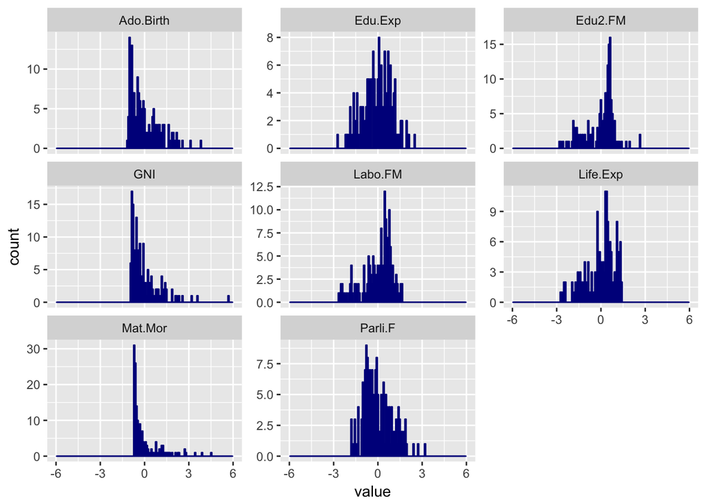

```r
# Show a graphical overview of the data
# Access to ggplot2 and tidyr
library(ggplot2)
library(tidyr)

# For easier overview of the data, the data set is scaled and class changed from numeric to data frame.
human_scaled<-scale(human)
human_scaled<-as.data.frame(human_scaled)

# Next scaled data is gathered to key-value pairs and plotted for visualization of the data.
gather(human_scaled)%>%ggplot(aes(value))+facet_wrap("key", scales="free_y", )+geom_histogram(bins=155, col="darkblue")+xlim(-6,6)
```

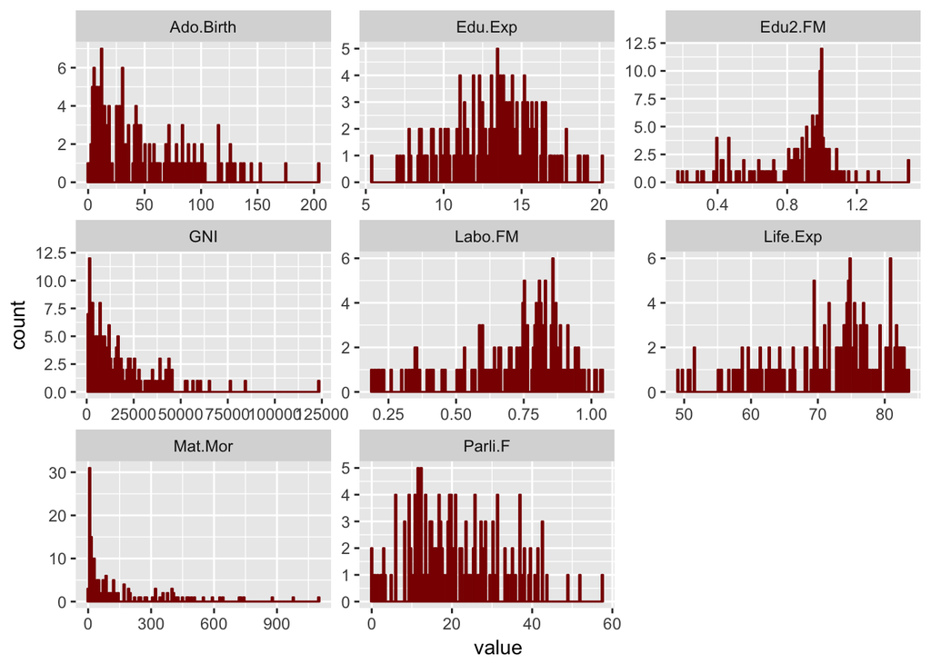

```r
# To see how scaling affected another histograms are made for the original data.
gather(human)%>%ggplot(aes(value))+facet_wrap("key", scales="free", )+geom_histogram(bins=155, col="darkred")
```

From the blue histograms (scaled values) it is perhaps easier to see, which variables are normally distributed, and which are not. Ado.Birth, GNI and Mat.Mor are not following the normal distribution. From red histograms (not-scaled histograms) it is obvious that data set doesn’t have negative values, which makes sense, because none of the variables in the data table can have negative value.